# Knobe (2003) Replication Analysis

Bradley Kennedy

09/10/2019

## Current R Version:

```
## [1] "R version 3.6.1 (2019-07-05)"
```

Check if required packages need to be installed, if so, install

```r
if (!require("readxl")) install.packages("readxl"); library(readxl)
if (!require("plyr")) install.packages("plyr"); library(plyr)
if (!require("tidyr")) install.packages("tidyr"); library(tidyr)
if (!require("reshape2")) install.packages("reshape2"); library(reshape2)
if (!require("polycor")) install.packages("polycor"); library(polycor)
if (!require("corrgram")) install.packages("corrgram"); library(corrgram)
if (!require("esc")) install.packages("esc"); library(esc)
if (!require("psych")) install.packages("psych"); library(psych)
if (!require("lsr")) install.packages("lsr"); library(lsr)
if (!require("ggplot2")) install.packages("ggplot2"); library(ggplot2)
if (!require("dplyr")) install.packages("dplyr"); library(dplyr)
if (!require("Hmisc")) install.packages("Hmisc"); library(Hmisc)
if (!require("rcompanion")) install.packages("rcompanion"); library(rcompanion)
if (!require("beepr")) install.packages("beepr"); library(beepr)
```

Check for package updates from cloud.r-project.org

```r
update.packages(ask=FALSE, repos = "https://cloud.r-project.org")
```

## Data Wrangling

Import the original data file

```r
Data_forCleaning <- read_excel("Data_forCleaning.csv",
                               col_types = c("text", "text", "text",
                                             "numeric", "text", "numeric", "text",
                                             "numeric", "text", "numeric", "text"))
```

Demographic information

```r
All_Age <- describe(as.numeric(Data_forCleaning$`4. Please enter your age`))
sd(as.numeric(Data_forCleaning$`4. Please enter your age`), na.rm = TRUE)
```

```
## [1] 9.320499
```

```r
Age_bySexIdentity <- describeBy(as.numeric(Data_forCleaning$`4. Please enter your age`),
            group = as.factor(Data_forCleaning$`3. Please enter your gender identity`))
```

Seperate each experimental condition into a seperate dataframe, removing any lines with NA, renaming column names

```r
Exp1_Harm <- select(Data_forCleaning, 4:5)
Exp1_Harm <- na.omit(Exp1_Harm)
names(Exp1_Harm) <- c("Chairman_HA_Blame", "Chairman_HA_Intent")
Exp1_Help <- select(Data_forCleaning, 6:7)
Exp1_Help <- na.omit(Exp1_Help)
names(Exp1_Help) <- c("Chairman_HE_Praise", "Chairman_HE_Intent")
Exp2_Harm <- select(Data_forCleaning, 8:9)
Exp2_Harm <- na.omit(Exp2_Harm)
names(Exp2_Harm) <- c("Lieutenant_HA_Blame", "Lieutenant_HA_Intent")
Exp2_Help <- select(Data_forCleaning, 10:11)
Exp2_Help <- na.omit(Exp2_Help)
names(Exp2_Help) <- c("Lieutenant_HE_Praise", "Lieutenant_HE_Intent")
```

Convert yes no responses to Yes=1 and No=0

```r
Exp1_Harm <- mutate_at(Exp1_Harm, vars(2:2), funs(ifelse( . == "Yes",1 , ifelse( . == "No", 0, .))))
Exp1_Harm <- transform(Exp1_Harm, Chairman_HA_Intent = as.numeric(Chairman_HA_Intent))
Exp1_Help <- mutate_at(Exp1_Help, vars(2:2), funs(ifelse( . == "Yes",1 , ifelse( . == "No", 0, .))))
Exp1_Help <- transform(Exp1_Help, Chairman_HE_Intent = as.numeric(Chairman_HE_Intent))
Exp2_Harm <- mutate_at(Exp2_Harm, vars(2:2), funs(ifelse( . == "Yes",1 , ifelse( . == "No", 0, .))))
Exp2_Harm <- transform(Exp2_Harm, Lieutenant_HA_Intent = as.numeric(Lieutenant_HA_Intent))
Exp2_Help <- mutate_at(Exp2_Help, vars(2:2), funs(ifelse( . == "Yes",1 , ifelse( . == "No", 0, .))))
Exp2_Help <- transform(Exp2_Help, Lieutenant_HE_Intent = as.numeric(Lieutenant_HE_Intent))
```

## Descriptive Statistics - INTENT - Experiment 1

Harm Condition (How many said Yes, it was intentional)

```r
Sum_Yes_Exp1HA <- sum(Exp1_Harm[,2]==1)
Percentage_Yes_Exp1HA <- round((Sum_Yes_Exp1HA/44)*100)
Sum_Yes_Exp1HA
```

```
## [1] 38
```

```r
Percentage_Yes_Exp1HA
```

```
## [1] 86
```

Harm Condition (How many said No, it was NOT intentional)

```r
Sum_No_Exp1HA <- sum(Exp1_Harm[,2]==0)
Percentage_No_Exp1HA <- round((Sum_No_Exp1HA/44)*100)
Sum_No_Exp1HA
```

```
## [1] 6
```

```r
Percentage_No_Exp1HA
```

```
## [1] 14
```

Help Condition (How many said Yes, it was intentional)

```r
Sum_Yes_Exp1HE <- sum(Exp1_Help[,2]==1)
Percentage_Yes_Exp1HE <- round((Sum_Yes_Exp1HE/44)*100)
Sum_Yes_Exp1HE
```

```
## [1] 3
```

```r
Percentage_Yes_Exp1HE
```

```
## [1] 7
```

Help Condition (How many said No, it was NOT intentional)

```r
Sum_No_Exp1HE <- sum(Exp1_Help[,2]==0)
Percentage_No_Exp1HE <- round((Sum_No_Exp1HE/44)*100)
Sum_No_Exp1HE
```

```
## [1] 41
```

```r
Percentage_No_Exp1HE
```

```
## [1] 93
```

## Descriptive Statistics - INTENT - Experiment 2

Harm Condition (How many said Yes, it was intentional)

```r
Sum_Yes_Exp2HA <- sum(Exp2_Harm[,2]==1)
Percentage_Yes_Exp2HA <- round((Sum_Yes_Exp2HA/44)*100)
Sum_Yes_Exp2HA
```

```
## [1] 43
```

```r
Percentage_Yes_Exp2HA
```

```
## [1] 98
```

Harm Condition (How many said No, it was NOT intentional)

```r
Sum_No_Exp2HA <- sum(Exp2_Harm[,2]==0)
Percentage_No_Exp2HA <- round((Sum_No_Exp2HA/44)*100)
Sum_No_Exp2HA
```

```
## [1] 1
```

```r
Percentage_No_Exp2HA
```

```
## [1] 2
```

Help Condition (How many said Yes, it was intentional)

```r
Sum_Yes_Exp2HE <- sum(Exp2_Help[,2]==1)
Percentage_Yes_Exp2HE <- round((Sum_Yes_Exp2HE/44)*100)
Sum_Yes_Exp2HE
```

```
## [1] 15
```

```r
Percentage_Yes_Exp2HE
```

```
## [1] 34
```

Help Condition (How many said No, it was NOT intentional)

```r
Sum_No_Exp2HE <- sum(Exp2_Help[,2]==0)
Percentage_No_Exp2HE <- round((Sum_No_Exp2HE/44)*100)
Sum_No_Exp2HE
```

```
## [1] 29
```

```r
Percentage_No_Exp2HE
```

```
## [1] 66
```

## Chi Square Tests

Data Prep for Chi Square, moving sum of ‘Yes’ and sum of ‘No’ for Exp 1 to seperate table

```r
Exp1_Intent <- matrix(c(Sum_Yes_Exp1HA,Sum_Yes_Exp1HE,Sum_No_Exp1HA,Sum_No_Exp1HE), ncol=2)
colnames(Exp1_Intent) <- c('Harm', 'Help')
rownames(Exp1_Intent) <- c('Yes','No')
```

Data Prep for Chi Square, moving sum of ‘Yes’ for Exp 2 to seperate table

```r
Exp2_Intent <- matrix(c(Sum_Yes_Exp2HA,Sum_Yes_Exp2HE,Sum_No_Exp2HA,Sum_No_Exp2HE), ncol=2)
colnames(Exp2_Intent) <- c('Harm', 'Help')
rownames(Exp2_Intent) <- c('Yes','No')
```

Chi Square, test difference between response for Exp1

```r
chisq.exp1 <- chisq.test(Exp1_Intent)
chisq.exp1
```

```
##
##  Pearson's Chi-squared test with Yates' continuity correction
##
## data:  Exp1_Intent
## X-squared = 52.791, df = 1, p-value = 3.71e-13
```

```r
esc_chisq(chisq = chisq.exp1$statistic,p=chisq.exp1$p.value,totaln = 88 ,es.type = "d")
```

```
##
## Effect Size Calculation for Meta Analysis
##
##      Conversion: chi-squared-value to effect size d
##     Effect Size:   2.4490
##  Standard Error:   0.3371
##        Variance:   0.1136
##        Lower CI:   1.7883
##        Upper CI:   3.1096
##          Weight:   8.8023
```

Chi Square, test difference between response for Exp2

```r
chisq.exp2 <- chisq.test(Exp2_Intent)
chisq.exp2
```

```
##
##  Pearson's Chi-squared test with Yates' continuity correction
##
## data:  Exp2_Intent
## X-squared = 36.869, df = 1, p-value = 1.263e-09
```

```r
esc_chisq(chisq = chisq.exp2$statistic,p=chisq.exp2$p.value,totaln = 88,es.type = "d")
```

```
##
## Effect Size Calculation for Meta Analysis
##
##      Conversion: chi-squared-value to effect size d
##     Effect Size:   1.6983
##  Standard Error:   0.2797
##        Variance:   0.0782
##        Lower CI:   1.1501
##        Upper CI:   2.2465
##          Weight:  12.7828
```

## Descriptive Statistics - PRAISE/BLAME

Mean amount of Blame for Harmful SE

```r
Mean_Blame <- round(mean(c(Exp1_Harm[,1],Exp2_Harm[,1])),digits=2)
Mean_Blame
```

```
## [1] 4.8
```

SD Blame for Harmful SE

```r
SD_Blame <- sd(c(Exp1_Harm[,1],Exp2_Harm[,1]))
SD_Blame
```

```
## [1] 1.348981
```

Mean amount of Praise for Helpful SE

```r
Mean_Praise <- round(mean(c(Exp1_Help[,1],Exp2_Help[,1])),digits=2)
Mean_Praise
```

```
## [1] 2.11
```

SD Praise for Helpful SE

```r
SD_Praise <- sd(c(Exp1_Help[,1],Exp2_Help[,1]))
SD_Praise
```

```
## [1] 1.738224
```

Create one table of all

```r
All_table <- table(c(Exp1_Harm[,1],Exp1_Help[,1],Exp2_Harm[,1],Exp2_Help[,1]),
                   c(Exp1_Harm[,2],Exp1_Help[,2],Exp2_Harm[,2],Exp2_Help[,2]))
All_table <- bind_cols(Exp1_Harm,Exp1_Help,Exp2_Harm,Exp2_Help)
colnames(All_table) <- c("PB","Intent","PB","Intent","PB","Intent","PB","Intent")
All_table <- data.frame(PB = c(All_table[,1],All_table[,3],All_table[,5],All_table[,7]),
                        Intent = c(All_table[,2],All_table[,4],All_table[,6],All_table[,8]))
All_table$Agent <- rep(c("Chairman", "Lieutenant"), each = 88)
All_table$Agent <- as.factor(All_table$Agent)
All_table$Condition <- rep(c("Harm", "Help"), each = 44)
All_table$Condition <- as.factor(All_table$Condition)
All_table$Experiment <- rep(1:2, each=88)
All_table$Experiment <- as.factor(All_table$Experiment)
All_table$Intent <- as.factor(All_table$Intent)
```

Median Praise/Blame ratings for Help/Harm Conditions

```r
medianPB_help <- median(c(Exp1_Help[,1],Exp2_Help[,1]))
medianPB_help
```

```
## [1] 3
```

```r
medianPB_harm <- median(c(Exp1_Harm[,1],Exp2_Harm[,1]))
medianPB_harm
```

```
## [1] 5
```

Create Table of Praise/Blame ratings and Harm/Help Intention ratings for Correlation and T test

```r
Corr_table <- table(c(Exp1_Harm[,1],Exp1_Help[,1],Exp2_Harm[,1],Exp2_Help[,1]),
                   c(Exp1_Harm[,2],Exp1_Help[,2],Exp2_Harm[,2],Exp2_Help[,2]))
Corr_table <- bind_cols(Exp1_Harm,Exp1_Help,Exp2_Harm,Exp2_Help)
Corr_table <- data.frame(Praise = c(Corr_table[,3],Corr_table[,7]),
                         Blame = c(Corr_table[,1],Corr_table[,5]),
                        PraiseIntent = c(Corr_table[,4],Corr_table[,8]),
                        BlameIntent = c(Corr_table[,2],Corr_table[,6]))
```

## T test to test differences between Praise and Blame ratings

```r
PB_ttest <- t.test(Corr_table$Praise,Corr_table$Blame, var.equal = TRUE)
PB_ttest
```

```
##
##  Two Sample t-test
##
## data:  Corr_table$Praise and Corr_table$Blame
## t = -11.434, df = 174, p-value < 2.2e-16
## alternative hypothesis: true difference in means is not equal to 0
## 95 percent confidence interval:
##  -3.144746 -2.218891
## sample estimates:
## mean of x mean of y
##  2.113636  4.795455
```

```r
PB_ttest_effectsize<- cohensD(x=Corr_table$Praise,y=Corr_table$Blame)
PB_ttest_effectsize
```

```
## [1] 1.72373
```

```r
cohen.d.ci(PB_ttest_effectsize,n=88,alpha=.05)
```

```
##         lower  effect    upper
## [1,] 1.229352 1.72373 2.210724
```

## Mann-Whitney U test

Examining the ratings of praise/blame comparing help vs. harm

```r
wilcox.test(PB ~ Condition, data = All_table)
```

```
##
##  Wilcoxon rank sum test with continuity correction
##
## data:  PB by Condition
## W = 6848, p-value < 2.2e-16
## alternative hypothesis: true location shift is not equal to 0
```

Mann-Whitney U effect size (r; Small: 0.1, Medium: 0.3, Large: >0.5)

```r
wilcoxonR(x  = All_table$PB,
          g  = All_table$Condition,
          ci = TRUE)
```

```
##       r lower.ci upper.ci
## 1 0.674    0.571    0.754
```

## Mann-Whitney U test 2

Examining the ratings of praise/blame for intentional yes/no

```r
wilcox.test(PB ~ Intent, data = All_table)
```

```
##
##  Wilcoxon rank sum test with continuity correction
##
## data:  PB by Intent
## W = 1425.5, p-value = 5.088e-13
## alternative hypothesis: true location shift is not equal to 0
```

Mann-Whitney U effect size (r; Small: 0.1, Medium: 0.3, Large: >0.5)

```r
wilcoxonR(x  = All_table$PB,
          g  = All_table$Intent,
          ci = TRUE)
```

```
##        r lower.ci upper.ci
## 1 -0.544   -0.651   -0.434
```

## Correlation between ratings of Praise with help intentionality

```r
P.Help_Correlation <- cor.test(Corr_table$Praise,Corr_table$PraiseIntent)
P.Help_Correlation
```

```
##
##  Pearson's product-moment correlation
##
## data:  Corr_table$Praise and Corr_table$PraiseIntent
## t = 0.2956, df = 86, p-value = 0.7682
## alternative hypothesis: true correlation is not equal to 0
## 95 percent confidence interval:
##  -0.1787758  0.2397021
## sample estimates:
##        cor
## 0.03185933
```

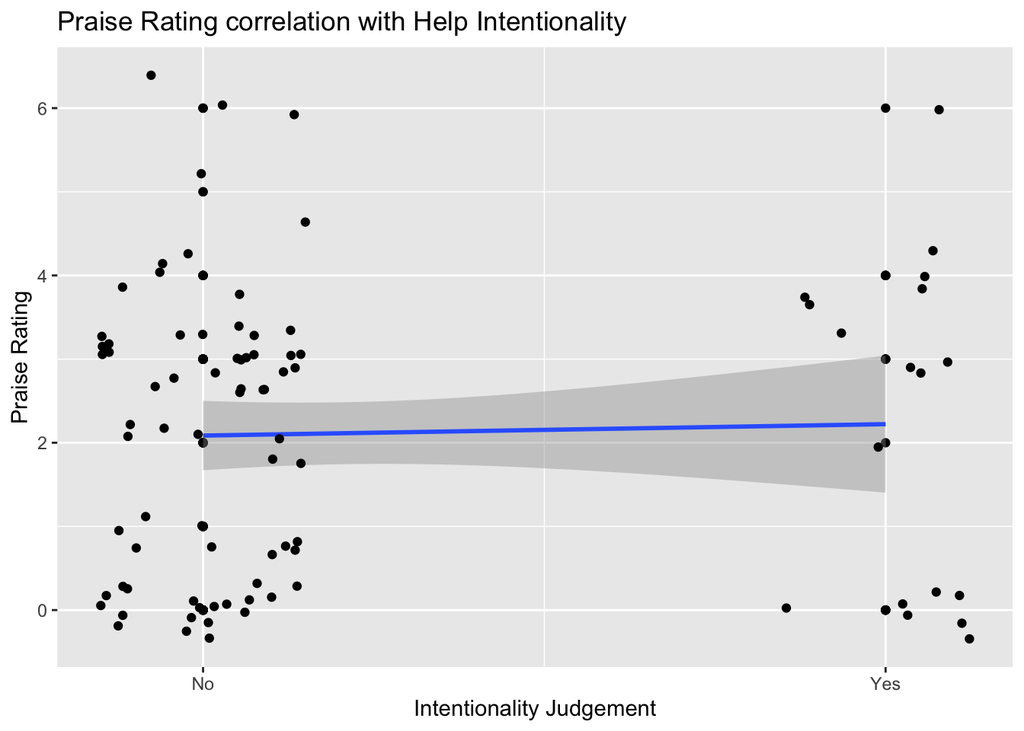

```r
P.Help_plot <- ggplot(Corr_table, aes(x=PraiseIntent, y=Praise)) +
                      geom_point() +
                      geom_smooth(method=lm) +
                      geom_jitter(width = 0.15) +
                      labs(x = "Intentionality Judgement", y = "Praise Rating",
                          title = "Praise Rating correlation with Help Intentionality") +
                      scale_x_continuous(breaks = c(0,1),labels = c("No", "Yes"))

P.Help_plot
```

## Correlation between ratings of Blame with harm intentionality

```r
B.Harm_Correlation <- cor.test(Corr_table$Blame,Corr_table$BlameIntent)
B.Harm_Correlation
```

```
##
##  Pearson's product-moment correlation
##
## data:  Corr_table$Blame and Corr_table$BlameIntent
## t = 1.6419, df = 86, p-value = 0.1043
## alternative hypothesis: true correlation is not equal to 0
## 95 percent confidence interval:
##  -0.03643224  0.37026271
## sample estimates:
##       cor
## 0.1743403
```

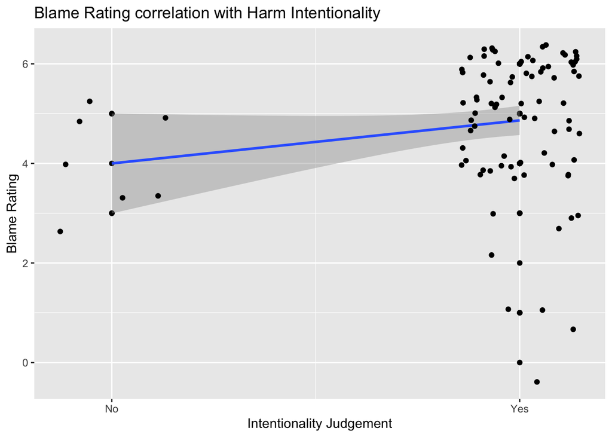

```r
B.Harm_plot <- ggplot(Corr_table, aes(x=BlameIntent, y=Blame)) +
                      geom_point() +
                      geom_smooth(method=lm) +
                      geom_jitter(width = 0.15) +
                      labs(x = "Intentionality Judgement", y = "Blame Rating",
                           title = "Blame Rating correlation with Harm Intentionality") +
                      scale_x_continuous(breaks = c(0,1),labels = c("No", "Yes"))

B.Harm_plot
```

## Correlation between all ratings of Praise/Blame with all intention ratings

```r
PB_Correlation <- cor.test(All_table$PB,as.numeric(All_table$Intent))
PB_Correlation
```

```
##
##  Pearson's product-moment correlation
##
## data:  All_table$PB and as.numeric(All_table$Intent)
## t = 7.919, df = 174, p-value = 2.715e-13
## alternative hypothesis: true correlation is not equal to 0
## 95 percent confidence interval:
##  0.3970137 0.6157468
## sample estimates:
##      cor
## 0.514707
```

```r
PB_Corr_effectsize <- cohensD(x=All_table$PB,y=as.numeric(All_table$Intent))
cohen.d.ci(PB_Corr_effectsize,n=176,alpha=.05)
```

```
##          lower   effect    upper
## [1,] 0.9410951 1.266643 1.589138
```

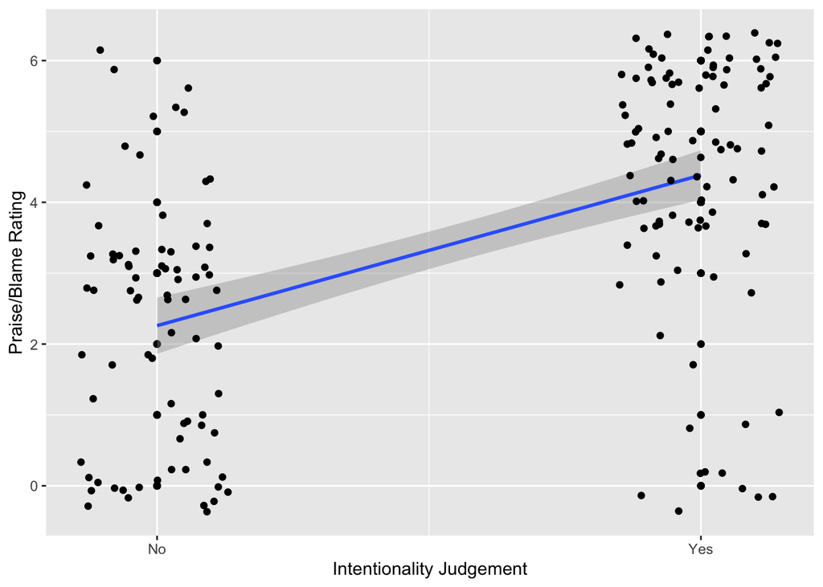

```r
PB_plot <- ggplot(All_table, aes(x=as.numeric(Intent), y=PB)) +
                  geom_point() +
                  geom_smooth(method=lm) +
                  geom_jitter(width = 0.15) +
                  labs(x = "Intentionality Judgement", y = "Praise/Blame Rating") +
                  scale_x_continuous(breaks = c(1,2), labels = c("No", "Yes"))
PB_plot
```

## Raincloud Plot

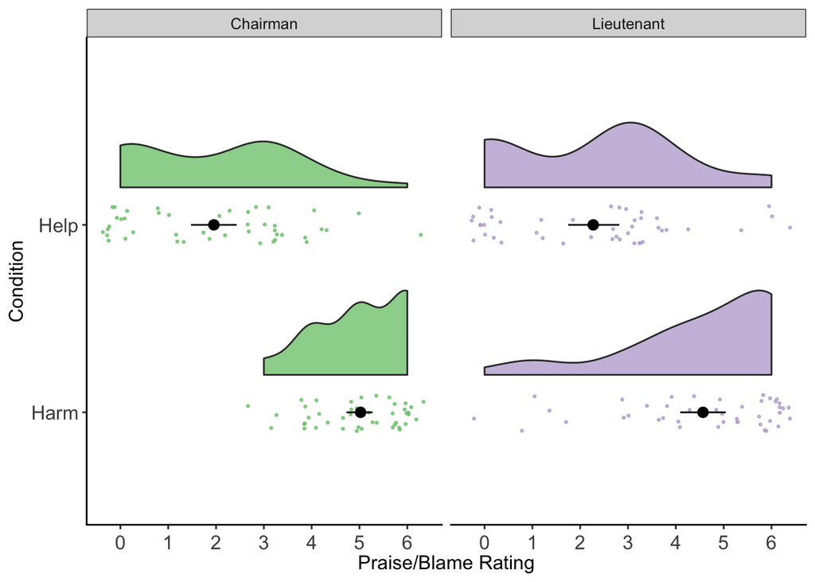

```r
source("https://gist.githubusercontent.com/benmarwick/2a1bb0133ff568cbe28d/raw/fb53bd97121f7f9ce947837ef1a4c65a73bffb3f/geom_flat_violin.R")
raincloud_theme = theme(text = element_text(size = 12),
                        axis.title.x = element_text(size = 12),
                        axis.title.y = element_text(size = 12),
                        axis.text = element_text(size = 12),
                        axis.text.x = element_text(vjust = 0.5),
                        legend.title=element_text(size=12),
                        legend.text=element_text(size=12),
                        legend.position = "right",
                        plot.title = element_text(lineheight=.8, face="bold", size = 16),
                        panel.border = element_blank(),
                        panel.grid.minor = element_blank(),
                        panel.grid.major = element_blank(),
                        axis.line.x = element_line(colour = 'black', size=0.5, linetype='solid'),
                        axis.line.y = element_line(colour = 'black', size=0.5, linetype='solid'))

PB_Rain <- ggplot(data = All_table,
                 aes(y = All_table$PB, x = All_table$Condition, fill = All_table$'Agent')) +
  geom_flat_violin(position = position_nudge(x = .2, y = 0), alpha = .8, trim=TRUE) +
  geom_point(aes(y = PB, color = All_table$Agent),
             position = position_jitter(width = .10), size = .5, alpha = 0.8) +
  expand_limits(x = 3) + guides(fill = FALSE) + guides(color = FALSE) +
  scale_color_brewer(palette = "Accent") + scale_fill_brewer(palette = "Accent") +
  coord_flip() + theme_bw() + raincloud_theme + labs(x="Condition") +
  scale_y_continuous(breaks = seq(0,6,by = 1)) + ylab("Praise/Blame Rating") +
  stat_summary(fun.data="mean_cl_boot", colour="black", size=.5) +
  facet_wrap(vars(Agent))
PB_Rain
```

## GLM - impact of praise/blame on yes/no response

Replacement of knobes correlation

```r
model1 <- glm(Intent ~ PB, family = binomial, data = All_table)
summary(model1)
```

```
##
## Call:
## glm(formula = Intent ~ PB, family = binomial, data = All_table)
##
## Deviance Residuals:
##     Min       1Q   Median       3Q      Max
## -1.9964  -0.9356   0.5414   0.7146   1.9860
##
## Coefficients:
##             Estimate Std. Error z value Pr(>|z|)
## (Intercept)  -1.8223     0.3850  -4.733 2.21e-06 ***
## PB            0.6114     0.1004   6.091 1.12e-09 ***
## ---
## Signif. codes:  0 '***' 0.001 '**' 0.01 '*' 0.05 '.' 0.1 ' ' 1
##
## (Dispersion parameter for binomial family taken to be 1)
##
##     Null deviance: 241.23  on 175  degrees of freedom
## Residual deviance: 190.56  on 174  degrees of freedom
## AIC: 194.56
##
## Number of Fisher Scoring iterations: 3
```

```r
confint(model1)
```

```
##                  2.5 %     97.5 %
## (Intercept) -2.6255759 -1.1074184
## PB           0.4250932  0.8208681
```

## GLM - impact of help/harm condition in exp1 and exp2

Knobes chi square

```r
exp1_filter <- All_table$Experiment=="1"
model_exp1 <- glm(Intent ~ Condition, family = binomial, data = All_table[exp1_filter,])
summary(model_exp1)
```

```
##
## Call:
## glm(formula = Intent ~ Condition, family = binomial, data = All_table[exp1_filter,
##     ])
##
## Deviance Residuals:
##     Min       1Q   Median       3Q      Max
## -1.9962  -0.3758  -0.3758   0.5415   2.3176
##
## Coefficients:
##               Estimate Std. Error z value Pr(>|z|)
## (Intercept)     1.8458     0.4393   4.202 2.65e-05 ***
## ConditionHelp  -4.4608     0.7421  -6.011 1.84e-09 ***
## ---
## Signif. codes:  0 '***' 0.001 '**' 0.01 '*' 0.05 '.' 0.1 ' ' 1
##
## (Dispersion parameter for binomial family taken to be 1)
##
##     Null deviance: 121.584  on 87  degrees of freedom
## Residual deviance:  56.955  on 86  degrees of freedom
## AIC: 60.955
##
## Number of Fisher Scoring iterations: 5
```

```r
confint(model_exp1)
```

```
##                   2.5 %    97.5 %
## (Intercept)    1.060626  2.813995
## ConditionHelp -6.110441 -3.141960
```

```r
exp2_filter <- All_table$Experiment=="2"
model_exp2 <- glm(Intent ~ Condition, family = binomial, data = All_table[exp2_filter,])
summary(model_exp2)
```

```
##
## Call:
## glm(formula = Intent ~ Condition, family = binomial, data = All_table[exp2_filter,
##     ])
##
## Deviance Residuals:
##     Min       1Q   Median       3Q      Max
## -2.7511  -0.9131   0.2144   0.2144   1.4671
##
## Coefficients:
##               Estimate Std. Error z value Pr(>|z|)
## (Intercept)      3.761      1.012   3.718 0.000201 ***
## ConditionHelp   -4.420      1.060  -4.169 3.06e-05 ***
## ---
## Signif. codes:  0 '***' 0.001 '**' 0.01 '*' 0.05 '.' 0.1 ' ' 1
##
## (Dispersion parameter for binomial family taken to be 1)
##
##     Null deviance: 112.93  on 87  degrees of freedom
## Residual deviance:  66.01  on 86  degrees of freedom
## AIC: 70.01
##
## Number of Fisher Scoring iterations: 6
```

```r
confint(model_exp2)
```

```
##                   2.5 %    97.5 %
## (Intercept)    2.239760  6.636331
## ConditionHelp -7.343388 -2.752087
```

```r
model2 <- glm(Intent ~ Condition, family = binomial, data = All_table)
summary(model2)
```

```
##
## Call:
## glm(formula = Intent ~ Condition, family = binomial, data = All_table)
##
## Deviance Residuals:
##     Min       1Q   Median       3Q      Max
## -2.2501  -0.6765   0.4072   0.4072   1.7815
##
## Coefficients:
##               Estimate Std. Error z value Pr(>|z|)
## (Intercept)     2.4485     0.3940   6.215 5.12e-10 ***
## ConditionHelp  -3.8067     0.4744  -8.024 1.02e-15 ***
## ---
## Signif. codes:  0 '***' 0.001 '**' 0.01 '*' 0.05 '.' 0.1 ' ' 1
##
## (Dispersion parameter for binomial family taken to be 1)
##
##     Null deviance: 241.23  on 175  degrees of freedom
## Residual deviance: 138.04  on 174  degrees of freedom
## AIC: 142.04
##
## Number of Fisher Scoring iterations: 5
```

```r
confint(model2)
```

```
##                   2.5 %    97.5 %
## (Intercept)    1.749313  3.317302
## ConditionHelp -4.812511 -2.934915
```

## GLM - interaction between condition and experiment on intentionality

Replacement of knobes correlation

```r
full_model <- glm(Intent ~ Condition*Experiment, family = binomial, data = All_table)
summary(full_model)
```

```
##
## Call:
## glm(formula = Intent ~ Condition * Experiment, family = binomial,
##     data = All_table)
##
## Deviance Residuals:
##     Min       1Q   Median       3Q      Max
## -2.7511  -0.3758   0.2144   0.5415   2.3176
##
## Coefficients:
##                           Estimate Std. Error z value Pr(>|z|)
## (Intercept)                1.84583    0.43930   4.202 2.65e-05 ***
## ConditionHelp             -4.46079    0.74210  -6.011 1.84e-09 ***
## Experiment2                1.91537    1.10281   1.737   0.0824 .
## ConditionHelp:Experiment2  0.04034    1.29424   0.031   0.9751
## ---
## Signif. codes:  0 '***' 0.001 '**' 0.01 '*' 0.05 '.' 0.1 ' ' 1
##
## (Dispersion parameter for binomial family taken to be 1)
##
##     Null deviance: 241.23  on 175  degrees of freedom
## Residual deviance: 122.96  on 172  degrees of freedom
## AIC: 130.96
##
## Number of Fisher Scoring iterations: 6
```

```r
confint(full_model)
```

```
##                                 2.5 %    97.5 %
## (Intercept)                1.06062609  2.813995
## ConditionHelp             -6.11044067 -3.141960
## Experiment2                0.08871659  4.877463
## ConditionHelp:Experiment2 -3.12221573  2.411378
```